# Lesson notes | R Markdown

# 1 Introduction

The {rmarkdown} package enables you to generate dynamic documents by combining formatted text and results produced by R code. With R Markdown, you can create documents in various formats such as HTML, PDF, Word, and many others, making it a versatile tool for exporting, communicating, and sharing your analysis results.

This document itself was created using R Markdown. While there is an entire book dedicated to R Markdown, we will cover some of the essential concepts here.

Note that working with R Markdown requires using a lot of the graphical user interface (GUI) tools in RStudio. Because of this, the written notes in this lesson will not be as detailed as in other lessons. For deeper understanding, we recommend that you follow along with the accompanying video tutorial.

# Learning objectives

- Create and knit an R Markdown document that includes code and free text
- Output documents in multiple formats, including HTML, PDF, Word, PowerPoint, and flexdashboards
- Understand basic Markdown syntax
- Use R chunk options, such as *eval*, *echo*, and *message*
- Know the syntax for inline R code
- Recognize useful packages for table formatting in R Markdown
- Understand how to use the {here} package to set the project folder as the working directory in R Markdown files

# 2 Project setup

To begin, open RStudio and click on the *File* menu. Select *New Project…* and then click on *New Directory*. Choose a name for your project and specify the directory where you want to store it. Remember the location for future reference. Once you have filled out these fields, click *Create Project*.

Next, let’s set up some folders within the project. In the *Files* pane, click on *New Folder* and name it “data”. Click *OK*. This folder will store the project’s data. Create another folder called “rmd” to store your R Markdown documents.

# 3 Create a new document

An R Markdown document is a simple text file with the `.Rmd` extension.

To create a new R Markdown document in RStudio, go to the *File* menu, choose *New file*, and then select *R Markdown…*. If prompted, install the necessary packages. Once RStudio has the required packages, the following dialog box will appear:

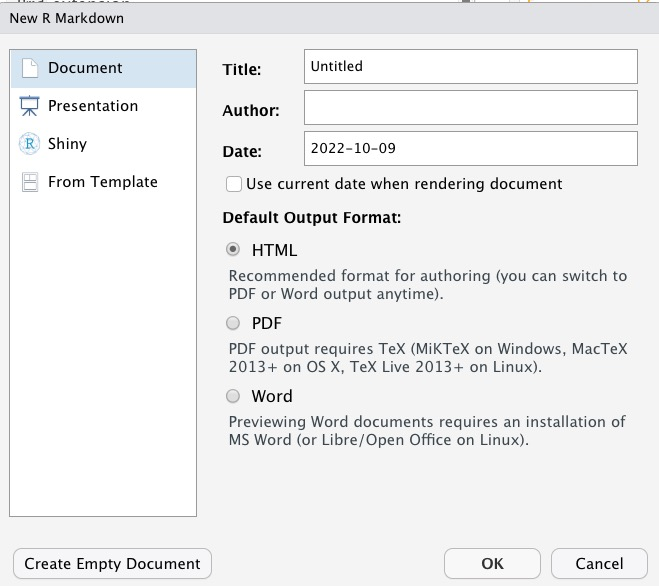

For now, keep the default values and click OK. A file with sample content will be displayed.

Experiment with editing some of the text in the file. Notice that it consists of free text and code sections.

Save your file using `Cmd/Ctrl` + `S`, and make sure to give it the “.Rmd” extension. For example, “ebola_analysis.Rmd”. Save it in the “rmd” folder you created earlier.

To render the document, click on the “knit” button at the top right:

[figure not shown]

This will generate an HTML output that looks like this:

[figure not shown]

The rendered file will be stored in the same directory as your Rmd file, with the same name but ending in “.html” instead of “.rmd”.

HTML stands for Hypertext Markup Language and is the standard format used for most documents on the web.

# 4 R Markdown Header (YAML)

Let’s return to the rest of the Rmd file and examine it part by part.

The first part of the document is its *header*, also known as “YAML” (Yet Another Markup Language). The name is intended to be humorous.

```yaml
---
title: "Untitled"
output: html_document
date: "2022-10-09"
---
```

The YAML header must be located at the very beginning of the document, delimited by three dashes (`---`) before and after.

This header contains the document’s metadata, such as its title, author, date, and various options that allow you to configure and customize the entire document and its rendering. For example, the line `output: html_document` specifies that the generated document should be in HTML format.

You can change the `html_document` text to experiment with other formats.

## 4.1 Word Document

If you set the output to “word_document”, and click to tknit the file, the rendered document will look like this:

[figure not shown]

Image of the R Markdown document open in the Microsoft Word program

A “.docx” version of your document will be created in the “rmd” folder.

## 4.2 PowerPoint Document

When the output is set to “powerpoint_document”, the result will be:

[figure not shown]

Image of the R Markdown document open in the Microsoft PowerPoint program

## 4.3 PDF Document

If you change the output setting to “pdf_document”, you can obtain the same document in PDF format (you may be prompted to install tinytex on your computer, see below):

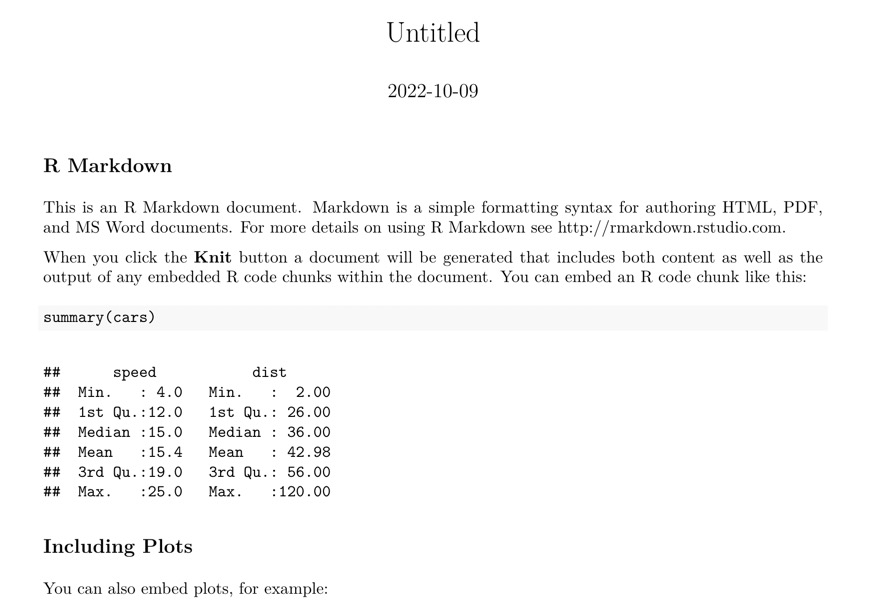

For PDF generation, you must have a working `LaTeX` installation on your system. If not, Yihui Xie’s `tinytex` extension aims to simplify the installation of a minimal `LaTeX` distribution regardless of your machine’s operating system.

To use it, first install the extension with `install.packages('tinytex')`, then run the following command in the console (expect a download of about 200MB): `tinytex::install_tinytex()`. More information is available on [the tinytex website](https://yihui.name/tinytex/).

## 4.4 Prettydoc

To try the “prettydoc” format, type `install.packages('prettydoc')` into the console and press *Enter*. The output format for prettydoc is slightly different from the previous three. You need to use `prettydoc::html_pretty` in the `output` section. When you knit a prettydoc, you should see something like this:

[figure not shown]

Image of the R Markdown document as a prettydoc

## 4.5 Flexdashboard

You can even create a simple dashboard format. First, run `install.packages('flexdashboard')`. Then, set the `output` to `flexdashboard::flex_dashboard` and knit. The result will be similar to the following:

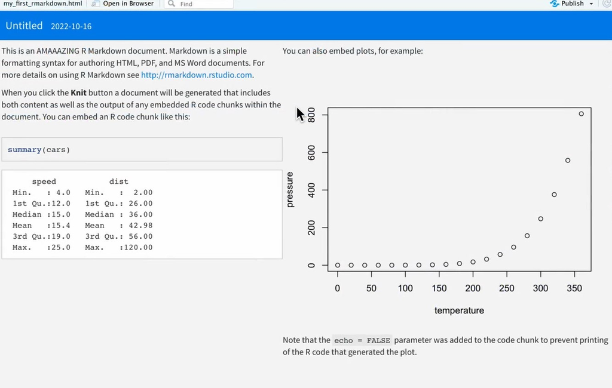

Image of the R Markdown document as a flexdashboard

Note that it does not yet have tabs. To create tabs in a flexdashboard, change some of your double hashtags `##` to single hashtags `#`. This will modify the header style for those sections, and flexdashboard will render those headers as tabs.

Many other formats are available, and we encourage you to explore them on your own!

# 5 Visual vs Source mode

Rmarkdown documents can be edited in either a “Source” mode or a “Visual” mode.

You can switch into visual mode for a given document using the toolbars. There is a pair of buttons to toggle between the modes:

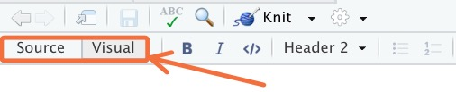

What’s the difference between these two modes?

In source mode, you see the raw markdown syntax.

**Markdown** is a simple set of conventions for adding formatting to plain text. For example, to italicize text, you wrap it in asterisks `*text here*`, and to start a new header, you use the pound sign `#`. We will learn these in detail below.

In visual mode, you see a Microsoft Word-like view with a toolbar for easy formatting.

This means you don’t have to remember the syntax for markdown elements. For example, if you want to make a section of text bold, you can simply highlight that piece of text and click on the bold button in the toolbar.

While visual mode is much easier to use, we will teach you markdown syntax here for three reasons:

1. Visual mode can sometimes be buggy, and to debug this, you’ll need to switch to source mode.
2. Understanding markdown syntax is useful outside of Rmarkdown.
3. Visual mode is not available in RStudio’s collaborative mode, which you may want to use.

# 6 Markdown syntax

In the “Help” tab of the top RStudio menu, if you look up “Markdown Quick Reference”, you will find a wide variety of RMD options available.

You can define titles of different levels by starting a line with one or more `#`:

```
# Level 1 title
## Level 2 Title
### Level 3 Title
```

The body of the document consists of text that follows the *Markdown* syntax. A Markdown file is a text file that contains lightweight markup to help set heading levels or format text. For example, the following text:

```
This is text with *italics* and **bold**.

You can define bulleted lists:

- first element
- second element
```

Will generate the following formatted text:

> This is text with *italics* and **bold**.

> You can define bulleted lists:
> - first element
> - second element

Note that you need spaces before and after lists, as well as keeping the listed items on separate lines. Otherwise, they will all crunch together rather than making a list.

We see that words placed between asterisks are italicized, and lines that begin with a dash are transformed into a bulleted list.

The Markdown syntax allows for other formatting, such as the ability to insert links or images. For example, the following code:

```
[Example Link](https://example.com)
```

… will give the following link:

> [Example Link](https://example.com)

We can also embed images. If you’re in *Source* mode, type:

`![what you want the subtitle to say](images/picture_name.jpg)`, replacing “what you want the subtitle to say” (it can also be blank), “images” with the name of the image folder in your project, and “picture_name.jpg” with the name of the image you want to use. In *Visual* mode, you can open the folder that holds your image on your computer and drag-and-drop the image from the folder onto the page you’re building. Alternatively, place the cursor where you want the image, click the button above marked with a “picture” icon, follow the prompts, and insert your image where the cursor is. This will also create an “images” folder in your project (if it doesn’t already exist) and put the image file into the “images” folder.

When titles have been defined, clicking on the *Show document outline* icon on the far right of the toolbar associated with the R Markdown file will display a table of contents automatically generated from the titles, allowing for easy navigation within the document:

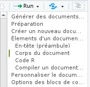

Dynamic TOC

## 6.1 Customizing the generated document

The generated document can be customized by modifying options in the document’s preamble. RStudio offers a graphical interface to change these options more easily. To access it, click on the gear icon to the right of the *Knit* button and choose *Output Options…*

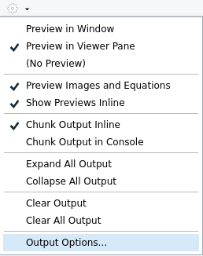

R Markdown Output Options

A dialog box will appear, allowing you to select the desired output format and various options depending on the format:

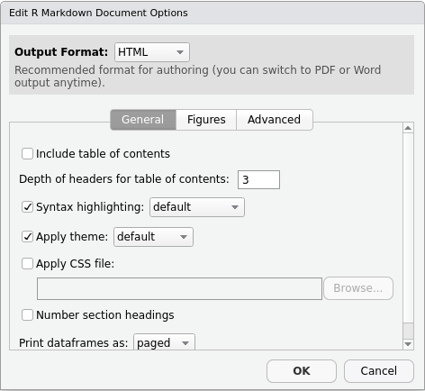

R Markdown Output Options Dialog

For example, with the HTML format, the *General* tab allows you to specify if you want a table of contents, its depth, the themes to apply for the document and the syntax highlighting of the R blocks, etc. The *Figures* tab allows you to change the default dimensions of the generated graphics.

When you change options, RStudio will modify the preamble of your document. For instance, if you choose to show a table of contents and change the syntax highlighting theme, your header will become something like:

```
---
title: "R Markdown Review"
output:
   html_document:
     highlight: kate
     toc: yes
---
```

You can also modify the options directly by editing the preamble.

Note that it is possible to specify different options depending on the format, for example:

```
---
title: "R Markdown Review"
output:
  html_document:
    highlight: kate
    toc: yes
  pdf_document:
    fig_caption: yes
    highlight: kate
---
```

The complete list of possible options is available on [the official documentation site](http://rmarkdown.rstudio.com/formats.html) (which is very comprehensive and well-made) and on the cheat sheet and reference guide, accessible from RStudio via the *Help* menu, then *Cheatsheets*.